# Chapter 2 Computing Notes

## Data Splitting

- load the data twoClassData from Applied Predictive Modeling. Two columns for predictiors and 208 sample

```r
str(predictors)
```

```
## 'data.frame':    208 obs. of  2 variables:
##  $ PredictorA: num  0.158 0.655 0.706 0.199 0.395 ...
##  $ PredictorB: num  0.1609 0.4918 0.6333 0.0881 0.4152 ...
```

```r
str(classes)
```

```
##  Factor w/ 2 levels "Class1","Class2": 2 2 2 2 2 2 2 2 2 2 ...
```

- Base function sample() can sample, but caret’s createDataPartition() can do straitfied sampling based on classes in training set

```r
set.seed(1)
trainingRows <- createDataPartition(classes,
                                p = 0.8,
                                list = FALSE)

trainPredictors <- predictors[trainingRows, ]
trainClasses <- classes[trainingRows]
testPredictors <- predictors[-trainingRows, ]
testClasses <- classes[-trainingRows]
```

- Could also use maximum dissimilarity sampling, use caret maxdissim()

## Resampling

- createDataPartition can be used with argument times to generate multiple splits

```r
set.seed(1)
repeatedSplits <- createDataPartition(trainClasses,
                                      p=0.8,
                                      times = 3)
str(repeatedSplits)
```

```
## List of 3
##  $ Resample1: int [1:135] 1 2 4 5 6 8 9 10 11 12 ...
##  $ Resample2: int [1:135] 2 3 4 6 7 8 9 11 14 15 ...
##  $ Resample3: int [1:135] 4 5 6 7 8 9 11 13 14 15 ...
```

- caret package also has functions createResamples() for bootstrap, createFolds() for k-fold cross validation, and createMultiFolds() for repeated cross validation.
- In practice, can use caret functions to automatically create resampled data sets, fit models and evaluate performance

## Basic Model Building in R

- Aim: to fit a 5-nearest neighbour classification model to the data. There are multiple functions that could be used, we will use knn3() function in caret
- R ises formula interface and the non-formula (matrix) interface for fitting models. NOTE that not all R functions have both interfaces

```r
#modelFunction(price ~ numBed + numBath + acres,
#              data = housingData)

#modelFunction(x = housePredictors, y = price)
```

- The formula interface is handy as can directly manipulate inputs, eg log(acres). However, it does not efficiently store the information, and can slow computations.
- The matric interface specifices all the predicors in a matrix or data frajme, and the outcome as a vector object
- Can directly fit the model (we will use train() function in a bit)

```r
trainPredictors <- as.matrix(trainPredictors)
knnFit <- knn3( x = trainPredictors, y = trainClasses, k = 5)
knnFit
```

```
## 5-nearest neighbor classification model
## Training set class distribution:
##
## Class1 Class2
##     89     78
```

- Now use the predict method

```r
testPredictions <- predict(knnFit, newdata= testPredictors, type = 'class')
str(testPredictions)
```

```
##  Factor w/ 2 levels "Class1","Class2": 2 2 1 1 2 2 2 2 2 2 ...
```

The value of the type argument varies accross different modeling functions.

## Determining Tuning Parameters

- focus here on the train() function
- For this example, will use SVM like a black box. We want to tune the cost parameter

```r
library(caret)
```

- Want to use all the predictors to determine the Class

```r
data(GermanCredit)
GermanCredit <- GermanCredit[, -nearZeroVar(GermanCredit)]
GermanCredit$CheckingAccountStatus.lt.0 <- NULL
GermanCredit$SavingsAccountBonds.lt.100 <- NULL
GermanCredit$EmploymentDuration.lt.1 <- NULL
GermanCredit$EmploymentDuration.Unemployed <- NULL
GermanCredit$Personal.Male.Married.Widowed <- NULL
GermanCredit$Property.Unknown <- NULL
GermanCredit$Housing.ForFree <- NULL

## Split the data into training (80%) and test sets (20%)
set.seed(100)
inTrain <- createDataPartition(GermanCredit$Class, p = .8)[[1]]
GermanCreditTrain <- GermanCredit[ inTrain, ]
GermanCreditTest  <- GermanCredit[-inTrain, ]
```

```r
##NEED TO MAKE THE TRAIN VALIDATION SPLIT
set.seed(1056)
svmFit <- train(Class ~ .,
                data = GermanCreditTrain,
                method = 'svmRadial')
```

- We would like to tailor the computations by overriding several defaults
- First, want to preprocess

```r
set.seed(1056)
svmFit <- train(Class ~ .,
                data = GermanCreditTrain,
                method = 'svmRadial',
                preProc = c('center', 'scale'))
```

- Note we can do PCA here as well (and I think spatialSign as well)
- The user can specify the cost values to investigate. With tuneLength = 10, the cost values 2^-2 to 2^7 are evaluated

```r
set.seed(1056)
svmFit <- train(Class ~ .,
                data = GermanCreditTrain,
                method = 'svmRadial',
                preProc = c('center', 'scale'),
                tuneLength = 10)
```

- By default, the basic bootstrap will be used to calculate performance measures. Repeated 10-fold cross-validation can be specified with the trainControl function.

```r
set.seed(1056)
svmFit <- train(Class ~ .,
                data = GermanCreditTrain,
                method = 'svmRadial',
                preProc = c('center', 'scale'),
                tuneLength = 10,
                trControl = trainControl(method = 'cv',
                                         number = 10,
                                         classProbs = TRUE))
svmFit
```

```
## Support Vector Machines with Radial Basis Function Kernel
##
## 800 samples
##  41 predictors
##   2 classes: 'Bad', 'Good'
##
## Pre-processing: centered, scaled
## Resampling: Cross-Validated (10 fold)
##
## Summary of sample sizes: 720, 720, 720, 720, 720, 720, ...
##
## Resampling results across tuning parameters:
##
##   C       Accuracy  Kappa      Accuracy SD  Kappa SD
##     0.25  0.75000   0.3621457  0.03773077   0.09398841
##     0.50  0.74875   0.3583850  0.03701070   0.09000414
##     1.00  0.75500   0.3615119  0.03545341   0.08971669
##     2.00  0.75125   0.3352532  0.03701070   0.10030851
##     4.00  0.74750   0.3161471  0.03322900   0.10820951
##     8.00  0.75500   0.3305751  0.03496029   0.10265553
##    16.00  0.74000   0.2817631  0.03106892   0.08099299
##    32.00  0.74750   0.2959647  0.02993047   0.09911545
##    64.00  0.74250   0.2829124  0.03184162   0.08323454
##   128.00  0.73250   0.2629528  0.02898755   0.08066541
##
## Tuning parameter 'sigma' was held constant at a value of 0.01377442
## Accuracy was used to select the optimal model using  the largest value.
## The final values used for the model were sigma = 0.01377442 and C = 1.
```

- Using the ‘pick the best’ approach, the most accurate model is chosen. selectFunction() allows to select model by best, oneSE or tolerance

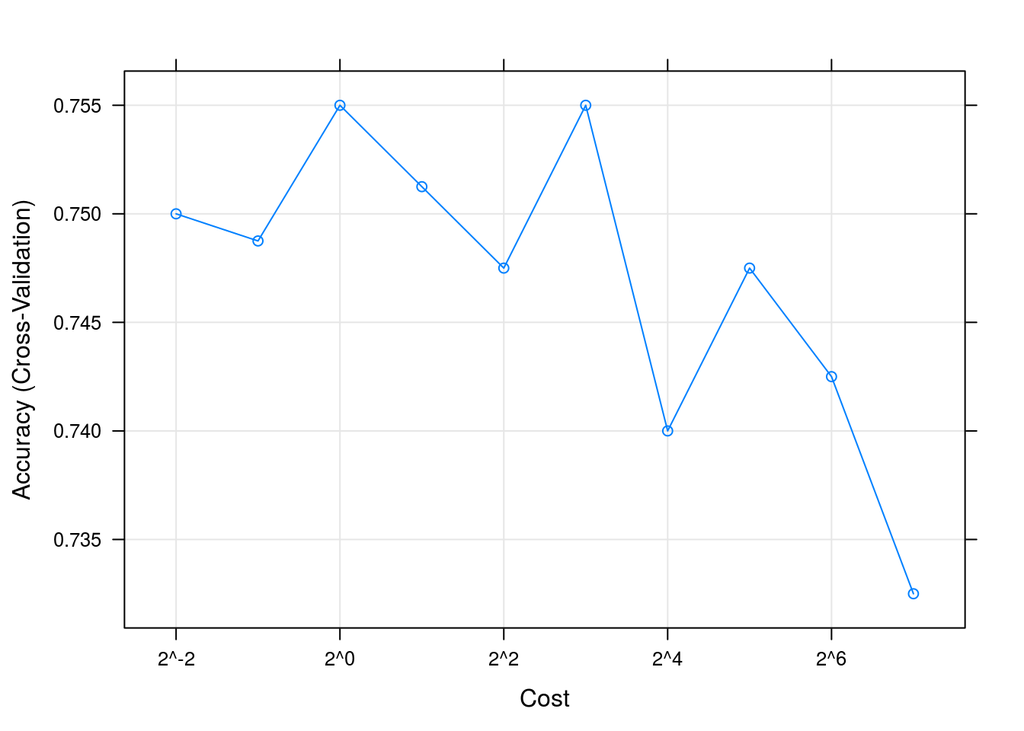

```r
plot(svmFit, scales = list(x = list(log = 2)))
```

- To predict new samples:

```r
predictedClasses <- predict(svmFit, newdata = GermanCreditTest)
str(predictedClasses)
```

```
##  Factor w/ 2 levels "Bad","Good": 1 1 2 2 1 2 2 2 2 1 ...
```

- Can get class probablilities using ‘type’ option

```r
predictedProbs <- predict(svmFit, newdata = GermanCreditTest,
                            type = "prob")
str(predictedProbs)
```

```
## 'data.frame':    200 obs. of  2 variables:
##  $ Bad : num  0.6155 0.5866 0.4748 0.0547 0.6668 ...
##  $ Good: num  0.384 0.413 0.525 0.945 0.333 ...
```

## Between-Model Comparisons

- want to compare the svm model to a simple glm

```r
set.seed(1056)
logisticReg <- train(Class ~ .,
                     data = GermanCreditTrain,
                     method = 'glm',
                     trControl = trainControl(method = 'cv',
                                              number = 10))

logisticReg
```

```
## Generalized Linear Model
##
## 800 samples
##  41 predictors
##   2 classes: 'Bad', 'Good'
##
## No pre-processing
## Resampling: Cross-Validated (10 fold)
##
## Summary of sample sizes: 720, 720, 720, 720, 720, 720, ...
##
## Resampling results
##
##   Accuracy  Kappa      Accuracy SD  Kappa SD
##   0.75875   0.3763929  0.03230175   0.08947374
##
##
```

To compare these two models based on cross-validation statistics, use the resamples() function. Since the random number seed was initialized prior to running the SVM and logistic models, paired accuracy measurements exist for each data set. First, we create a resamples object from the models:

```r
resamp <- resamples(list(SVM = svmFit, Logistic = logisticReg))
summary(resamp)
```

```
##
## Call:
## summary.resamples(object = resamp)
##
## Models: SVM, Logistic
## Number of resamples: 10
##
## Accuracy
##            Min. 1st Qu. Median   Mean 3rd Qu.  Max. NA's
## SVM      0.6875  0.7406 0.7562 0.7550  0.7844 0.800    0
## Logistic 0.7250  0.7281 0.7625 0.7588  0.7719 0.825    0
##
## Kappa
##            Min. 1st Qu. Median   Mean 3rd Qu.   Max. NA's
## SVM      0.1901  0.3242 0.3770 0.3615  0.4333 0.4595    0
## Logistic 0.2361  0.3035 0.3983 0.3764  0.4315 0.5270    0
```

- Evaluate the performance using diff()

```r
modelDifferences <- diff(resamp)
summary(modelDifferences)
```

```
##
## Call:
## summary.diff.resamples(object = modelDifferences)
##
## p-value adjustment: bonferroni
## Upper diagonal: estimates of the difference
## Lower diagonal: p-value for H0: difference = 0
##
## Accuracy
##          SVM    Logistic
## SVM             -0.00375
## Logistic 0.7078
##
## Kappa
##          SVM    Logistic
## SVM             -0.01488
## Logistic 0.5474
```